# Data Transformation Activity

## Babynames Assignment

```r
library(tidyverse)
#install.packages("babynames")
library(babynames)
```

### 1. Look at the data (1 pt)

The package babynames contains an object of the same name that contains all the data about babynames.The babynames dataset has historical information about births of babies in the U.S.

View and examine the data and its structure to understand what variables are contained within the data

```r
head(babynames)
```

```
## # A tibble: 6 × 5
##    year sex   name          n   prop
##   <dbl> <chr> <chr>     <int>  <dbl>
## 1  1880 F     Mary       7065 0.0724
## 2  1880 F     Anna       2604 0.0267
## 3  1880 F     Emma       2003 0.0205
## 4  1880 F     Elizabeth  1939 0.0199
## 5  1880 F     Minnie     1746 0.0179
## 6  1880 F     Margaret   1578 0.0162
```

```r
str(babynames)
```

```
## tibble [1,924,665 × 5] (S3: tbl_df/tbl/data.frame)
##  $ year: num [1:1924665] 1880 1880 1880 1880 1880 1880 1880 1880 1880 1880 ...
##  $ sex : chr [1:1924665] "F" "F" "F" "F" ...
##  $ name: chr [1:1924665] "Mary" "Anna" "Emma" "Elizabeth" ...
##  $ n   : int [1:1924665] 7065 2604 2003 1939 1746 1578 1472 1414 1320 1288 ...
##  $ prop: num [1:1924665] 0.0724 0.0267 0.0205 0.0199 0.0179 ...
```

### 2. Visually Explore the Data for Popular Girl Names (1 pt)

Filter the data for the names Emily, Kathleen, Alexandra, and Beverly.

```r
dat <- babynames %>%
  filter(name %in% c("Emily","Kathleen","Alexandra","Beverly"), sex=="F")
```

Visualize the resulting data in a line graph by mapping year to the x-axis, proportion of name (prop) to the y-axis and name to color.

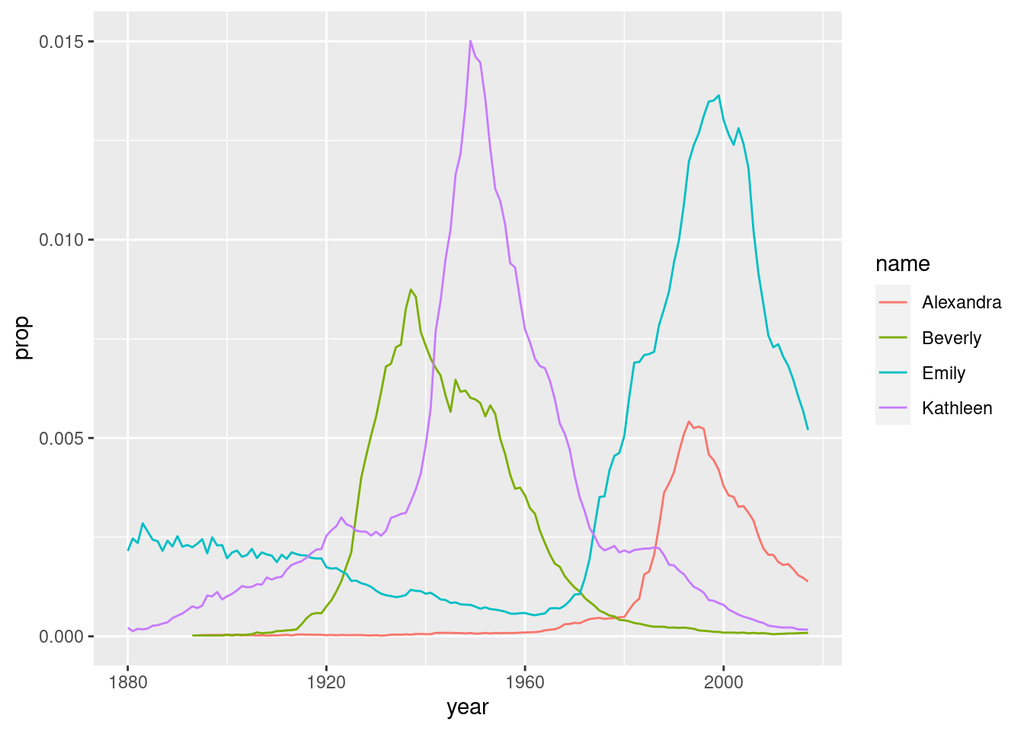

```r
ggplot(data = dat,aes(x = year,y = prop, colour=name))+
  geom_line()
```

Because in most countries assigned sex at birth is binary, there is no data on intersex, trans or non-binary names. In lieu of that, here’s the [Wikipedia page about gender-neutral names and naming laws](https://en.wikipedia.org/wiki/Unisex_name) around the world which will hopefully make you question why on earth we ascribe someone’s entire gender identity to a bunch of sounds and letters we use to label them.

### 3. Create a new variable for decade (2 pts)

Create a new column for decade Hint: formula to find decade: **floor(year/10)*10**

```r
new_dat <- mutate(.data = babynames, # the tibble you want to add a column to
                  decade = floor(year/10) *10) # new column name = what you want it to contain
head(new_dat)
```

```
## # A tibble: 6 × 6
##    year sex   name          n   prop decade
##   <dbl> <chr> <chr>     <int>  <dbl>  <dbl>
## 1  1880 F     Mary       7065 0.0724   1880
## 2  1880 F     Anna       2604 0.0267   1880
## 3  1880 F     Emma       2003 0.0205   1880
## 4  1880 F     Elizabeth  1939 0.0199   1880
## 5  1880 F     Minnie     1746 0.0179   1880
## 6  1880 F     Margaret   1578 0.0162   1880
```

### 4. Create a new dataframe that determines the mean proportion for each name by sex and decade. (2 pts)

For this I want you to explore the group_by() and summarize() functions.

```r
new_dat2 <- new_dat%>%
  group_by(name,sex,decade)%>%
  summarise(mean_prop = mean(prop))
```

### 5. Using your dataset from step 4, figure out the 5 most popular baby names for both sexes in the 1880 decade

```r
dat_1880 <- new_dat2 %>%
  filter(decade == 1880)%>%
  arrange(desc(mean_prop))

#m: John, William, James, George, Charles
#f: Mary, Anna, Emma, Elizabeth, Minnie
```

### 6. Using your dataset from step 4, create a visualization that tracks the popularity of the 5 most popular baby names in 1880 across the decades (4 pts)

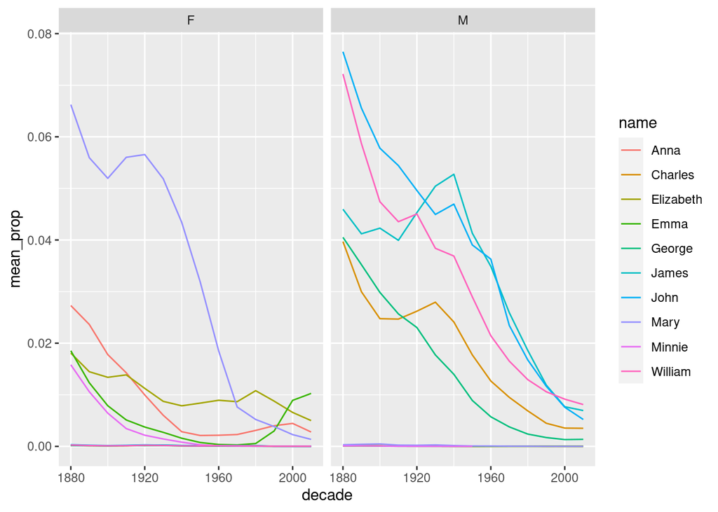

```r
names <- c("John", "William", "James", "George", "Charles","Mary", "Anna", "Emma", "Elizabeth", "Minnie")

viz <- new_dat2 %>%
  filter(name %in% names)%>%
  ggplot(mapping = aes(x = decade, y = mean_prop, color = name))+
  geom_line()+
  facet_wrap(~sex)

viz
```